# R Notebook

(Hidden) Libraries are loaded, and the data, PetFinder, is loaded from a cvs. PetFinder is cleaned to make it more user friendly.

```r
PetFinder %>%
  ggplot(aes(x = State)) +
  geom_bar() +
  ggtitle("Number of Pets by State")
```

[output not shown]

```r
#Importing data
url <-
  'https://en.wikipedia.org/wiki/List_of_Malaysian_states_by_GDP'
Malaysia <-
  url %>%
  read_html() %>%
  html_nodes(xpath= '/html/body/div[3]/div[3]/div[4]/div/table[1]') %>%
  html_table()
Malaysia <-
  Malaysia[[1]]
colnames(Malaysia)[1] <- "State"
```

After looking at the previous graph, I decided to look at data for the economy of the Malaysian states. The data table was taken from Wikipedia on the economy for each state in Malaysia.

```r
Joined <-
  left_join(PetFinder, Malaysia, by = "State")
colnames(Joined)[19] <- "GDP"
Joined <-
  Joined %>%
  mutate(GDP = gsub(pattern = ",", replacement = "", x = GDP)) %>%
  mutate(GDP = as.numeric(GDP))
head(Joined)
```

|  | Type | Name | Age | Breed1 | Breed2 | Gender | Color1 | Color2 | Color3 | MaturitySize | FurLength | Vaccinated | Dewormed | Sterilized | Health | Quantity | Fee | State | GDP | 2017 GDP current(RM Million) | 2016 GDP(RM Million) | 2015 GDP(RM Million) | 2014 GDP(RM Million) | 2013 GDP(RM Million) | 2012 GDP(RM Million) | 2011 GDP(RM Million) | 2010 GDP(RM Million) |
| --- | --- | --- | --- | --- | --- | --- | --- | --- | --- | --- | --- | --- | --- | --- | --- | --- | --- | --- | --- | --- | --- | --- | --- | --- | --- | --- | --- |
| 1 | Dog | Puppy | 2 | Mixed Breed | NA | Male | Black | NA | NA | Medium | Medium | No | No | No | Healthy | 1 | 150 | Selangor | 321069 | 300,627 | 280,698 | 239,968 | 226,964 | 212,645 | 200,906 | 187,434 | 177,718 |
| 2 | Cat | London | 24 | Domestic Short Hair | NA | Male | Brown | White | NA | Medium | Short | Yes | Yes | Yes | Healthy | 1 | 0 | Selangor | 321069 | 300,627 | 280,698 | 239,968 | 226,964 | 212,645 | 200,906 | 187,434 | 177,718 |
| 3 | Cat | Snowball | 20 | Domestic Short Hair | NA | Female | White | NA | NA | Medium | Short | Yes | Yes | Yes | Healthy | 1 | 150 | Selangor | 321069 | 300,627 | 280,698 | 239,968 | 226,964 | 212,645 | 200,906 | 187,434 | 177,718 |
| 4 | Cat | Malibu | 5 | Domestic Short Hair | Burmese | Female | Black | Gray | White | Medium | Short | Yes | Yes | Yes | Healthy | 1 | 100 | Selangor | 321069 | 300,627 | 280,698 | 239,968 | 226,964 | 212,645 | 200,906 | 187,434 | 177,718 |
| 5 | Dog | Lala Girl | 6 | Mixed Breed | NA | Female | Black | Brown | White | Medium | Short | Yes | Yes | Yes | Healthy | 1 | 150 | Selangor | 321069 | 300,627 | 280,698 | 239,968 | 226,964 | 212,645 | 200,906 | 187,434 | 177,718 |
| 6 | Dog | Tipo | 12 | Mixed Breed | Daschund | Female | Black | White | NA | Small | Short | Yes | Yes | Yes | Healthy | 1 | 0 | Selangor | 321069 | 300,627 | 280,698 | 239,968 | 226,964 | 212,645 | 200,906 | 187,434 | 177,718 |

In this chunk, I joined the two data tables together to make it easier to analyze the data together.

```r
mod_logit <- lm(Fee ~ GDP + Quantity,  data = Joined)
```

```r
msummary(mod_logit)
```

```
              Estimate Std. Error t value Pr(>|t|)
(Intercept)  1.723e+01  5.529e+00   3.116 0.001845 **
GDP          6.221e-05  1.948e-05   3.194 0.001417 **
Quantity    -3.337e+00  9.185e-01  -3.633 0.000284 ***

Residual standard error: 89.46 on 3669 degrees of freedom
  (276 observations deleted due to missingness)
Multiple R-squared:  0.006432,  Adjusted R-squared:  0.00589
F-statistic: 11.88 on 2 and 3669 DF,  p-value: 7.23e-06
```

```r
res <- 100
fake_grid <- expand.grid(
  GDP = seq(from = 280698, to = 5642, length.out = res),
  Quantity = seq(from = 20, to = 1, length.out = res))
```

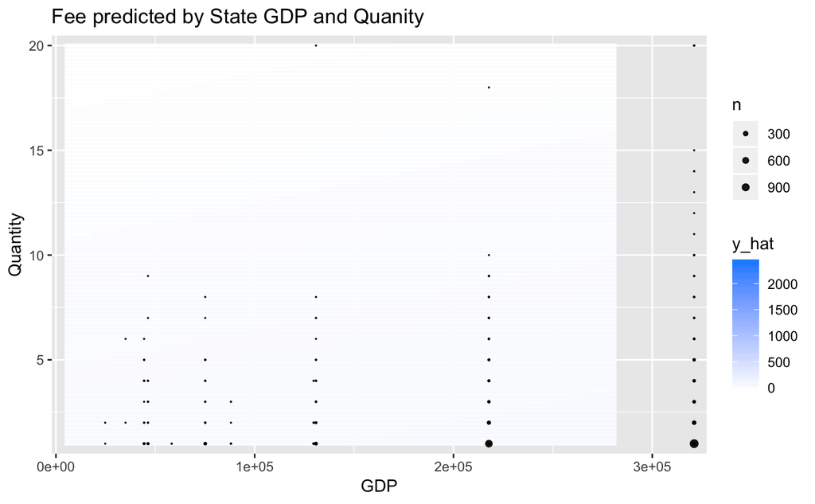

```r
pred_log <- predict(mod_logit, newdata = fake_grid, type = "response")
plot <-
  fake_grid %>%
  mutate("Logistic"= pred_log) %>%
  gather(key = "model", value = "y_hat", -GDP, -Quantity)
ggplot(data = plot, aes(x = GDP, y = Quantity)) +
  geom_tile(aes(fill = y_hat), color = NA) +
  geom_count(aes(fill = Fee), alpha = 0.9, data = Joined) +
  scale_fill_gradient(low = "white", high = "dodgerblue") +
  scale_color_manual(values = c("black", "red")) +
  scale_size(range = c(0, 2)) +
  scale_x_continuous(expand = c(0.02,0)) +
  scale_y_continuous(expand = c(0.02,0)) +
  ggtitle("Fee predicted by State GDP and Quanity")
```

I made a graph to help visualize the model’s prediction.

With an R-squared value close to zero, we can see that there is little correlation between the fee as the response variable and quantity if that type of animal and GDP of the state the animal is from. It may be beneficial for Malaysia have lower prices in lower states or transfer more expensive/desirable dogs to richer states.

```r
PetFinder <-
  PetFinder %>%
  mutate(Name = as.character(Name)) %>%
  mutate(Name = tolower(Name))
Sentiments <-
  get_sentiments("afinn")
```

Here I changed the PetFinder data to be more compatible with joining it with Sentiments. The sentiments data is a list of words and a numerical value that gives their sentiments. Sentiments is a continuous variable with positive and negative numbers that show the degree of positive or negative sentiment based on a survey.

```r
colnames(Sentiments)[1] <- "Name"
colnames(PetFinder)[2] <- "Name"
PetFinder_sentiment <-
  PetFinder %>%
  select(Name) %>%
  inner_join(Sentiments, PetFinder, by = 'Name') %>%
  filter(score < 0)
PetFinder_sentiment
```

| Name | score |
| --- | --- |
| angry | -3 |
| grey | -1 |
| rainy | -1 |
| toothless | -2 |
| emergency | -2 |
| shy | -1 |
| rainy | -1 |
| nosey | -2 |
| noisy | -1 |
| sneaky | -1 |

[output cut: 1 more lines]

I decided to see if any of the names of pets could have negative sentiments.

11 animals have names with negative scores. Shelters may want to consider changing these names to help get these animals adopted.